# Advanced Bioconductor: working with ENCODE (1)

Vincent J. Carey, stvjc at channing.harvard.edu

March 09, 2020

# 1 Introduction

The Encyclopedia of DNA Elements (ENCODE) is a collection of experimental results and computing resources devoted to elaboration of mechanisms of gene regulation. The project [main page](https://www.encodeproject.org/) is a good overview of its scope, involving four main organisms (human, mouse, worm and fly) and dozens of biotechnological innovations that are used to analyze gene structure and regulation. We will illustrate ways of using Bioconductor to acquire and interpret ENCODE resources.

Main aims for learners using this document:

- You will develop an understanding of the scope of the ENCODE project, particularly in terms of the variety of assays and experimental resources.
- You will be able to explore Bioconductor metadata about the project, surveying organism and cell identities, assay types, specific design objectives and assay outputs.
- You will become acquainted with the use of formal ontology to organize information about relationships between cell types and anatomic regions, as employed in ENCODE metadata.
- You will learn how to use the *GenomicFiles* package to manage information about terabytes of data resident in public cloud storage. Specifically the `reduceByFile` method operates on `GenomicFiles` instances to make targeted selections from indexed cloud-resident files, avoiding tedious downloading of large files.
- You will see how to “drill through” complex metadata to expose key aspects of informally annotated CRISPR interference experiments.
- You will be provided with code that permits comparison of different cell types with respect to TF binding patterns.
- With the programming framework provided in this narrative and exercises, you will be able to shift focus between different experimental aims and assay types to pose and answer questions about gene regulation of interest to you.

This document is part 1 of three parts – the second part addresses ATAC-seq, and the third addresses RNA-seq preceded by CRISPR-based interference.

# 2 Built-in surveys through ENCODExplorer metadata

We can use AnnotationHub to get information on ENCODE results that have been curated for direct use with Bioconductor. The *ENCODExplorer* package provides a metadata table, that we retrieve using *AnnotationHub*. We use the “full” table because it provides links to raw and processed data files curated in the cloud by the ENCODE project.

## 2.1 Using a local metadata cache

We’ll begin with a query to AnnotationHub to learn about resources whose metadata mentions “ENCODExplorerData”.

```r
library(AnnotationHub)
ah = AnnotationHub()
```

```
## snapshotDate(): 2020-02-28
```

```r
AnnotationHub::query(ah, "ENCODExplorerData")
```

```
## AnnotationHub with 4 records
## # snapshotDate(): 2020-02-28
## # $dataprovider: ENCODE Project
## # $species: NA
## # $rdataclass: data.table
## # additional mcols(): taxonomyid, genome, description,
## #   coordinate_1_based, maintainer, rdatadateadded, preparerclass, tags,
## #   rdatapath, sourceurl, sourcetype
## # retrieve records with, e.g., 'object[["AH69290"]]'
##
##             title
##   AH69290 | ENCODE File Metadata (Light, 2019-04-12 build)
##   AH69291 | ENCODE File Metadata (Full, 2019-04-12 build)
##   AH75131 | ENCODE File Metadata (Light, 2019-10-13 build)
##   AH75132 | ENCODE File Metadata (Full, 2019-10-13 build)
```

The recent ‘Full’ metadata table is over 90MB in size, so it takes a few moments to download from cloud (or load from cache, in case you have retrieved it previously).

```r
fm = ah[["AH75132"]] # implicitly retrieves if needed, or loads
```

```
## loading from cache
```

```r
dim(fm)
```

```
## [1] 454413    102
```

```r
table(fm$organism)
```

```
##
##   Caenorhabditis elegans     Drosophila ananassae  Drosophila melanogaster
##                    24796                        2                    29098
##    Drosophila mojavensis Drosophila pseudoobscura      Drosophila simulans
##                       26                       16                       17
##       Drosophila virilis        Drosophila yakuba             Homo sapiens
##                        2                        2                   332154
##           influenzavirus             Mus musculus
##                       22                    57662
```

We are working with 454413 records on 11 different organisms.

## 2.2 Filtering the metadata table

We focus on human samples, and limit to ChIP-seq experiments for now.

```r
# filter
hfm = fm[which(fm$organism == "Homo sapiens"),]
tail(sort(table(hfm$assay)))
```

```
##
##              eCLIP polyA plus RNA-seq      shRNA RNA-seq          DNase-seq
##               9516              11453              37938              40321
##   Histone ChIP-seq        TF ChIP-seq
##              78066              94038
```

```r
hfmt = hfm[which(hfm$assay == "TF ChIP-seq"),]
```

The proteins for which binding patterns can be assessed are in the `antibody_target` field:

```r
tail(sort(table(hfmt$antibody_target)))
```

```
##
##    RAD21-human   POLR2A-human    EP300-human eGFP-avictoria  YFP-avictoria
##            292            366            420            521            709
##     CTCF-human
##           1142
```

## 2.3 Managing the information with a GenomicFiles instance

We’ll manage the ChIP-seq data references with a *GenomicFiles* object. For convenience, we’ll focus on bigWig files.

```r
hfmtbw = hfmt[hfmt$file_type == "bigWig",]
dim(hfmtbw)
```

```
## [1] 24237   102
```

```r
table(hfmtbw$output_type)
```

```
##
##      base overlap signal fold change over control               raw signal
##                       55                    11229                      814
##                   signal   signal of unique reads           signal p-value
##                      494                      416                    11229
```

```r
library(GenomicFiles)
```

```r
gf1 = GenomicFiles(files=hfmtbw$cloud_metadata.url)
colData(gf1) = as(as.data.frame(hfmtbw), "DataFrame")
gf1
```

```
## GenomicFiles object with 0 ranges and 24237 files:
## files: ENCFF516HJR.bigWig, ENCFF118FLA.bigWig, ..., ENCFF134ANM.bigWig, ENCFF913WSO.bigWig
## detail: use files(), rowRanges(), colData(), ...
```

The `gf1` object reports only the “basename” component of the names of files managed. The actual filename (URL) for the first file is

```r
GenomicFiles::files(gf1)[1]
```

```
## [1] "https://encode-public.s3.amazonaws.com/2016/11/15/ab269604-0eeb-4fad-8754-c3cf4674fe91/ENCFF516HJR.bigWig"
```

A virtues of the GenomicFiles discipline is that we keep together the file identifiers and metadata about them. The following information is crucial to downstream use of the files.

```r
table(gf1$assembly)
```

```
##
## GRCh38   hg19
##  11218  13019
```

This table is very important, indicating that we are managing information for which two genomic coordinate systems are in play. In the introduction to Bioconductor, it is shown how `liftOver` can be used to translate between coordinate systems if needed.

We’ll focus on data collected with GRCh38 coordinates.

```r
gf1 = gf1[, which(gf1$assembly == "GRCh38")]
gf1
```

```
## GenomicFiles object with 0 ranges and 11218 files:
## files: ENCFF516HJR.bigWig, ENCFF324CIU.bigWig, ..., ENCFF345AKE.bigWig, ENCFF134ANM.bigWig
## detail: use files(), rowRanges(), colData(), ...
```

```r
gf = GenomicFiles(files=hfmtbw$cloud_metadata.url)
colData(gf) = as(as.data.frame(hfmtbw), "DataFrame")
```

## 2.4 Anatomic sources of samples

We’ll define a helper function to report on discrete properties of samples. This gives us clues on the contents of listings of biosample type and associated ontology labels.

```r
tls = function(x) t(t(head(sort(table(x), decreasing=TRUE))))
tls(gf1$biosample_name)
```

```
##
## x         [,1]
##   K562    2928
##   HepG2   1562
##   HEK293  1362
##   GM12878 1014
##   A549     786
##   MCF-7    702
```

```r
tls(gf1$biosample_ontology)
```

```
##
## x                                         [,1]
##   /biosample-types/cell_line_EFO_0002067/ 2928
##   /biosample-types/cell_line_EFO_0001187/ 1562
##   /biosample-types/cell_line_EFO_0001182/ 1362
##   /biosample-types/cell_line_EFO_0002784/ 1014
##   /biosample-types/cell_line_EFO_0001086/  786
##   /biosample-types/cell_line_EFO_0001203/  702
```

The use of ontology labeling helps us to organize information on samples. Bioconductor’s *ontoProc* package can be used to develop a simple hierarchical display. We focus on the Experimental Factor Ontology (EFO) tags, and take a very small subset of tags in use to obtain a tractable display in this document.

```r
library(ontoProc)
```

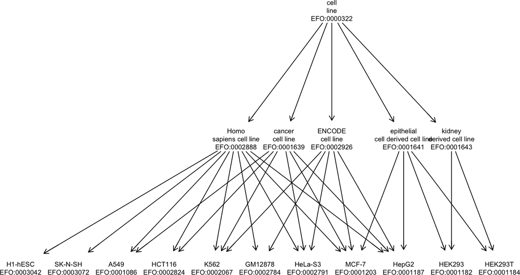

```r
ee = getEFOOnto()
tail(sort(table(hfmt$biosample_ontology)),12) -> ioi
nn = names(ioi[grep("EFO", names(ioi))])
tails = gsub(".*_", "", nn)
tailss = gsub("/", "", tails)
tt = paste0("EFO:", tailss)
onto_plot2(ee, tt, cex=.6)
```

It is noteworthy that in this display HEK293 is not linked to “Homo sapiens cell line”. This can be confirmed by visiting the [ontology lookup service](https://www.ebi.ac.uk/ols/ontologies/efo/terms?short_form=EFO_0001182). It is not uncommon to find gaps in curated data resources. Whether there is a justification for this particular omission is unclear.

## 2.5 Targeted sketching of peak scores

We’ll focus on the transcription factor CREB1. There are a modest number of samples in different cell lines. Some are treated with ethanol.

```r
gf1_creb1 = gf1[, which(gf1$target == "CREB1")]
table(gf1_creb1$treatment, gf1_creb1$biosample_name, exclude=NULL)
```

```
##
##           A549 HepG2 MCF-7
##   ethanol    4     0     0
##   <NA>       0     6    12
```

We’ll focus on samples with type `signal p-value`.

```r
table(gf1_creb1$output_type, gf1_creb1$biosample_name, exclude=NULL)
```

```
##
##                            A549 HepG2 MCF-7
##   fold change over control    2     3     6
##   signal p-value              2     3     6
```

```r
gf1_creb1_use = gf1_creb1[,
   which(gf1_creb1$output_type == "signal p-value")]
```

We will import a megabase of bigWig content from the files selected in this way, using `reduceByFile`:

```r
myr = GRanges("chr17", IRanges(66e6,67e6))
genome(myr) = "GRCh38"
rowRanges(gf1_creb1_use) = myr
sels = reduceByFile(gf1_creb1_use, MAP=function(range, file, ...) {
    sel = BigWigSelection(range)
    import.bw(file, selection=sel, genome=genome(myr)[1])
})
```

Here is our targeted sketch:

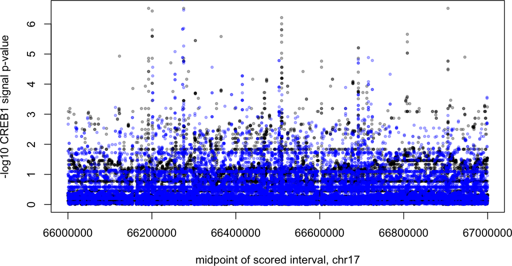

```r
lk1 = sels[[1]][[1]]
lk2 = sels[[2]][[1]]
plot(start(lk1)+.5*(width(lk1)), lk1$score, pch=19,
 xlab="midpoint of scored interval, chr17", ylab="-log10 CREB1 signal p-value",
 cex=.5, col=lava::Col("black", alpha=.3))
points(start(lk2)+.5*width(lk2), lk2$score, pch=19,
 col=lava::Col("blue", alpha=.3), cex=.5)
```

## 2.6 Summary

Review the following concepts before proceeding to exercises.

- We created the data.table instance `fm`, which is a creation of the developers of the ENCODExplorer package. We retrieved this table using *AnnotationHub*. The number of rows of `fm` is the number of metadata records related to experiments performed in ENCODE. The number of columns of `fm` is the number of metadata fields descriptive of the experiments.
- We filtered the metadata to `hfmtbw` to limit attention to bigWig files collected on human samples. The metadata field `cloud_metadata.url` gives the URL of each such file.
- The metadata fields `biosample_name` and `biosample_ontology` give information (less and more formal, respectively) about anatomic or cell-culture origins of samples. Ontological relationships among sample types can be useful for organizing investigations and the *ontoProc* `onto_plot2` function was used to sketch relationships among terms used to annotate samples.
- We extracted information from small numbers of bigWig files using `BigWigSelection` and `import.bw` from *rtracklayer*, applied to cloud-resident files through the `reduceByFile` method of *GenomicFiles*. The resulting scored GRanges instances were visualized using standard R plotting.

## 2.7 Exercises

### 2.7.1 Basic descriptive statistics

1. `gf1` represents data on 11218 ChIP-seq experiments for organism ‘Homo sapiens’ in bigWig format. Use the `cloud_metadata.file_size` `colData` component to state a) the median file size, and b) the total number of gigabytes of cloud-resident data to which `gf1` mediates access.

```r
median(as.numeric(gf1$cloud_metadata.file_size))
```

```
## [1] 917889226
```

```r
sum(as.numeric(gf1$cloud_metadata.file_size))/1e9
```

```
## [1] 11152.75
```

2. What is the most common ChIP-seq target protein studied in the 11218 experiments?

```r
tls(gf1$target)
```

```
##
## x                 [,1]
##   CTCF            1111
##   POLR2A           266
##   EP300            200
##   POLR2AphosphoS5  154
##   REST             122
##   EZH2             114
```

3. What is the most commonly studied cell type in the 11218 experiments?

```r
tls(gf1$biosample_name)
```

```
##
## x         [,1]
##   K562    2928
##   HepG2   1562
##   HEK293  1362
##   GM12878 1014
##   A549     786
##   MCF-7    702
```

4. Use the `fm` metadata table. For the application of the ATAC-seq assay to human samples, what is the most common `biosample_name`?

```r
 as_tibble(fm) %>% dplyr::filter(assay == "ATAC-seq" & organism=="Homo sapiens") %>%
    dplyr::select(biosample_name) %>% dplyr::group_by(biosample_name) %>%
    dplyr::summarise(n=dplyr::n()) %>% dplyr::arrange(desc(n))
```

```
## # A tibble: 30 x 2
##    biosample_name             n
##    <chr>                  <int>
##  1 foreskin keratinocyte    270
##  2 A549                      75
##  3 body of pancreas          48
##  4 dendritic cell            48
##  5 gastrocnemius medialis    48
##  6 sigmoid colon             44
##  7 transverse colon          44
##  8 thyroid gland             35
##  9 adrenal gland             33
## 10 breast epithelium         33
## # … with 20 more rows
```

5. *Chronology and scope of experimental agenda*. We can use the `date_created` field to document submission of assays of diverse types. We’ll use the `hfm` table for this.

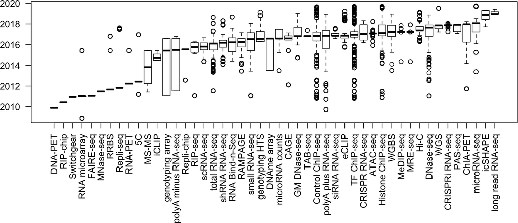

```r
newt = as_tibble(hfm) %>%
  dplyr::select(assay, date_created) %>%
  dplyr::mutate(ldate=lubridate::as_date(date_created))
par(las=2, mar=c(12,4,2,2))
ameds = sapply(split(newt$ldate, newt$assay), median)
with(newt, boxplot(split(ldate, assay)[order(ameds)]))
```

How many assays of type `long read RNA-seq` are present?

```r
sum(hfm$assay == "long read RNA-seq", na.rm=TRUE)
```

```
## [1] 8
```

6. RNA-seq preceded by CRISPR interference. We use the `dataset_description` to find out about genes knocked down in CRISPRi RNA-seq experiments. The language in that field is repetitious, and we massage its values a bit, using `gsub` and `mutate`, to get the name of the gene that was putatively knocked down.

```r
ii = (hfm %>% dplyr::filter(assay == "CRISPRi RNA-seq" & file_format=="tsv") %>%
  dplyr::mutate(targ = gsub(
    "RNA-seq on K562 cells treated by CRISPR interference targeting (..*).",
     "\\1", dataset_description)) %>%
  dplyr::select(investigated_as, targ) %>%
  dplyr::group_by(investigated_as, targ) %>% dplyr::summarise(n=dplyr::n()))
ii
```

```
## # A tibble: 77 x 3
## # Groups:   investigated_as [9]
##    investigated_as     targ       n
##    <chr>               <chr>  <int>
##  1 chromatin remodeler CTBP1      8
##  2 chromatin remodeler RBBP7     12
##  3 chromatin remodeler SETDB1    12
##  4 cofactor            CITED2     8
##  5 cofactor            DPF2       8
##  6 cofactor            ERF        8
##  7 cofactor            HMGA1      8
##  8 cofactor            HMGN3      4
##  9 cofactor            LDB1       8
## 10 cofactor            NFE2L1    16
## # … with 67 more rows
```

For how many different transcription factors, interfered with by CRISPR prior to RNA-seq, have tsv files been prepared?

```r
unique((ii %>% dplyr::filter(investigated_as == "transcription factor"))$targ)
```

```
##  [1] "ARID3A" "ATF3"   "BACH1"  "DLX1"   "FOXK2"  "GATA1"  "GATA2"  "HINFP"
##  [9] "HMBOX1" "HMGB2"  "HOXB4"  "HOXB9"  "HSF1"   "ILF2"   "JUND"   "KLF2"
## [17] "MAF1"   "MEIS2"  "MITF"   "MXD3"   "NFATC1" "NFYA"   "NFYB"   "NR2C2"
## [25] "NR2F2"  "NR4A1"  "NRF1"   "RELA"   "RFX5"   "RNF2"   "SIX5"   "SMAD5"
## [33] "SP1"    "SP2"    "SRF"    "STAT1"  "STAT2"  "STAT5A" "STAT6"  "TEAD4"
## [41] "TFDP1"  "THAP1"  "TRIM28" "UBTF"   "USF1"   "USF2"   "ZBTB33" "ZNF143"
## [49] "ZNF384" "ZNF395"
```

### 2.7.2 Retention of metadata; plotting

The following function, annotated in roxygen format, gathers the task of filtering bigWig data of a specific output type and target in a given genomic interval.

```r
#' import bigwig in an interval, given GenomicFiles for ENCODE bigWig files
#' @param gf GenomicFiles instance
#' @param target character(1) ChIP-seq target
#' @param biosample_names character() vector of cell types to retain
#' @param output_type character(1) defaults to "signal p-value"
#' @param selection GRanges instance, one range allowed
#' @export
 import_enc_bw = function(gf, target="CREB1",
   biosample_names = c("HepG2", "MCF-7", "A549"), output_type="signal p-value",
   selection= GRanges("chr17", IRanges(66e6,67e6), genome="GRCh38")) {
  stopifnot(length(selection)==1)
  gf_use = gf[, which(gf$target == target)]
  gf_use = gf_use[,
     which(gf_use$output_type == "signal p-value")]
  gf_use = gf_use[,
     which(gf_use$biosample_name %in% biosample_names)]
  rowRanges(gf_use) = selection
  ans = reduceByFile(gf_use, MAP=function(range, file, ...) {
      sel = BigWigSelection(range)
      import.bw(file, selection=sel, genome=genome(myr)[1])
  })
  ans = GRangesList(unlist(ans, recursive=FALSE))
  mcols(ans) = colData(gf_use)
  names(ans) = make.unique(mcols(ans)$biosample_name)
  ans
}
```

We can generate our sketch data with a pair of simple calls, assuming the construction of `gf1` is accomplished as above.

First, we generate the requested data on the available biosamples.

```r
skd = import_enc_bw(gf1)
```

A virtue of this approach is that the cell types (and all metadata) are bound to the scores:

```r
table(mcols(skd)$biosample_name)
```

```
##
##  A549 HepG2 MCF-7
##     2     3     6
```

To complete the task, we define a plotting function. We’ll call it to compare HepG2 and MCF-7 patterns in the selected interval.

```r
#' plot the result of a pair of import_enc_bw runs
#' @param impeb output of import_enc_bw
#' @param ylim limits of y axis
#' @param xlim limits of x axis
#' @param logy logical(1) whether or not to use log="y" in plot call
#' @param leg_frac_x numeric(1) fudge factor to move legend to the right of natural
#' position at xlim[1]
#' @export
plot_pair = function(impeb, ylim=c(1,500), xlim=c(66.1e6,66.3e6),
    logy=TRUE, leg_frac_x=.015) {
  stopifnot(length(impeb)==2)
  lk1 = impeb[[1]]
  lk2 = impeb[[2]]
  if (logy) {
   lk1 = lk1[which(lk1$score>0)]
   lk2 = lk2[which(lk2$score>0)]
   }
  seqn = as.character(seqnames(impeb[[1]]))[1]
  g = grep("chr", seqn)
  if (length(g)==0) seqn=paste0("chr", seqn)
  targ = mcols(impeb)$target[1]
  oty = mcols(impeb)$output_type[1]
  pspec = list(x=start(lk1)+.5*(width(lk1)), y=lk1$score, pch=19,
   xlab=sprintf("midpoint of scored interval, %s", seqn), ylab=sprintf("bigWig '%s' for %s", oty, targ),
   cex=.5, col=lava::Col("orange", alpha=.1), ylim=ylim, xlim=xlim, log=ifelse(logy, "y", ""))
  do.call(plot, pspec)
  points(start(lk2)+.5*width(lk2), lk2$score, pch=19,
   col=lava::Col("blue", alpha=.1), cex=.5)
  legend(xlim[1]+leg_frac_x*diff(xlim), ylim[2], pch=19, col=lava::Col(c("orange", "blue"), alpha=.4),
    legend=mcols(impeb)$biosample_name)
}
```

In the following calls, we select distinct pairs of samples from different cell types for overlaid visualization within pairs.

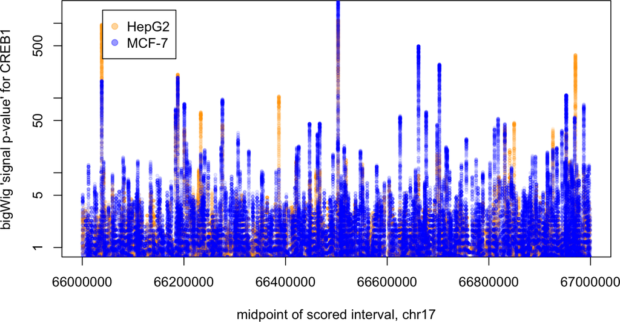

```r
plot_pair(skd[c("HepG2.2", "MCF-7")], ylim=c(1,1500), xlim=c(66e6, 67e6), leg_frac_x=.04)
```

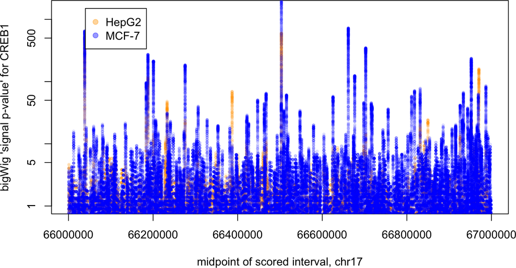

```r
plot_pair(skd[c("HepG2.1", "MCF-7.1")], ylim=c(1,1500), xlim=c(66e6, 67e6), leg_frac_x=.04)
```

1. What is the number of positions at which binding of CREB1 to HepG2 exhibits signal p-values consistently greater than those seen for MCF-7 in the two displays here? (0, 1, 4, 10)?
2. Use the following code to simplify the data on one HepG2 sample:

```r
s5 = skd[["HepG2.2"]]
GenomeInfoDb::seqlevelsStyle(s5) = "NCBI"
seqlevels(s5) = "17"
```

Using `genes(EnsDb.Hsapiens.v79)`, find the gene nearest the strongest peak for CREB1 in HepG2.

```r
g79 = ensembldb::genes(EnsDb.Hsapiens.v79::EnsDb.Hsapiens.v79)
g79[ nearest(s5[which.max(s5$score)], g79) ]
```

```
## GRanges object with 1 range and 6 metadata columns:
##                   seqnames            ranges strand |         gene_id
##                      <Rle>         <IRanges>  <Rle> |     <character>
##   ENSG00000154229       17 66302636-66810743      + | ENSG00000154229
##                     gene_name   gene_biotype seq_coord_system      symbol
##                   <character>    <character>      <character> <character>
##   ENSG00000154229       PRKCA protein_coding       chromosome       PRKCA
##                   entrezid
##                     <list>
##   ENSG00000154229     5578
##   -------
##   seqinfo: 319 sequences from GRCh38 genome
```

### 2.7.3 A different TF target, assayed in a breast cancer cell line.

Run the following code.

```
uu = import_enc_bw(gf1, target="FOXA1",
       selection=GRanges("chr6", IRanges(151.5e6,152.5e6)),
       biosample_names=c("A549", "MCF-7"))
plot_pair(uu[c("A549", "MCF-7")], xlim=c(151.5e6,152.5e6))
```

What gene is nearest to the strongest FOXA1 binding location seen in the sample named `MCF-7`?

```r
top = which.max(uu[["MCF-7"]]$score)
cand = uu[[7]][top]
seqlevelsStyle(cand) = "NCBI"
seqlevels(cand) = "6"
g79[nearest(cand, g79)]
```